Skip to main content

# Sensitivity analyses

- Show All Code
- Hide All Code
- View Source

How the association between SHBG and skeletal muscle mass depends on each covariate, on the measure of body size, on the specification and on the sample

**Code: setup, and checks that the statements of the text hold in the data**

```r
source("_common.R")
sen <- tab("tableS_sensitivity")
other <- sapply(paste0("B", 2:8), function(k) pct(SE[[k]]$ratio))            # one covariate other than waist removed
spec  <- sapply(paste0("E", 1:4), function(k) pct(SE[[k]]$ratio))
samp  <- sapply(paste0("F", 1:5), function(k) pct(SE[[k]]$ratio))
NL <- rows(R$nonlinearity)
P <- function(k) SE[[k]]$p
# statements made in the text must hold in the data
stopifnot(P("A5") > 0.05, P("B1") < 0.001, all(sapply(paste0("B", 2:8), P) > 0.05), P("A3") < 0.001, P("A4") > 0.05,
          all(sapply(c("C1", "C2", "C4", "C5", "C6"), P) > 0.05), P("C3") < 0.001, P("C7") < 0.001,
          P("D1") > 0.05, P("D2") > 0.05, all(sapply(c(paste0("E", 1:4), "F2", "F3", "F4", "F5"), P) > 0.05), P("F1") < 0.05,
          NL$p_nonlinearity[1] > 0.05, NL$p_nonlinearity[2] < 0.001, NL$p_per_10[1] > 0.05)
```

All estimates are percent differences in mean skeletal muscle mass per doubling of SHBG. The models are defined in Model definition. The primary model was defined after an initial model had been fitted, and the sensitivity analyses describe the robustness of a single association; they were not adjusted for multiple testing.

## Role of each covariate and of the measure of body size

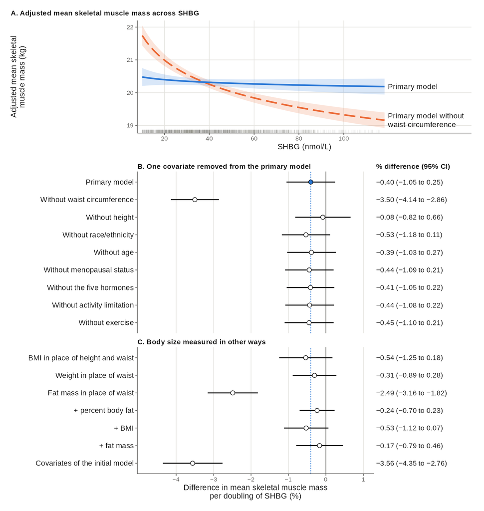

(A) Adjusted mean skeletal muscle mass across SHBG in the primary model (solid line) and in the primary model without waist circumference (dashed line); bands are 95% confidence intervals. (B) Percent difference in mean skeletal muscle mass per doubling of SHBG when one covariate is removed from the primary model; the five hormone covariates were removed together. (C) The same difference when body size is measured in other ways: another measure in place of height or waist circumference, a further measure added to the primary model (+), or the covariates of the initial model. The filled point and the dotted line mark the primary model. Fig 2 of the manuscript.

- **Waist circumference is the only covariate that matters.** Without it the estimate is −3.50% (95% CI −4.14 to −2.86). With any other covariate removed it stays between −0.53% and −0.08%.
- **The sequential models show the same step.** The estimate is −4.24% (95% CI −4.89 to −3.59) after adjustment for age, race/ethnicity and height, and −0.48% (95% CI −1.12 to 0.16) once waist circumference is added.
- **The result does not depend on waist circumference as the measure of body size.** With body mass index in place of height and waist circumference the estimate is −0.54% (95% CI −1.25 to 0.18), and with weight in place of waist circumference −0.31% (95% CI −0.89 to 0.28). It stays close to zero when percent body fat (−0.24%), body mass index (−0.53%) or fat mass (−0.17%) is added to the primary model.
- **The exception is body composition from impedance as the only measure of adiposity.** With fat mass in place of waist circumference the estimate is −2.49% (95% CI −3.16 to −1.82), and with the covariates of the initial model −3.56% (95% CI −4.35 to −2.76).

### Why the impedance-based measures behave differently

Percent body fat is a proportion. It correlates weakly with absolute muscle mass (ρ = 0.18) and less strongly with SHBG (ρ = −0.31) than waist circumference does (ρ = −0.46), so it captures less of what the two variables share. In addition, percent body fat and fat mass come from the same impedance measurement as skeletal muscle mass: the fat-free mass implied by weight and percent body fat has a correlation of 0.95 with skeletal muscle mass. These variables are partly determined by the outcome, which makes them poor measures of body size for this purpose.

## Scaling, specification and sample

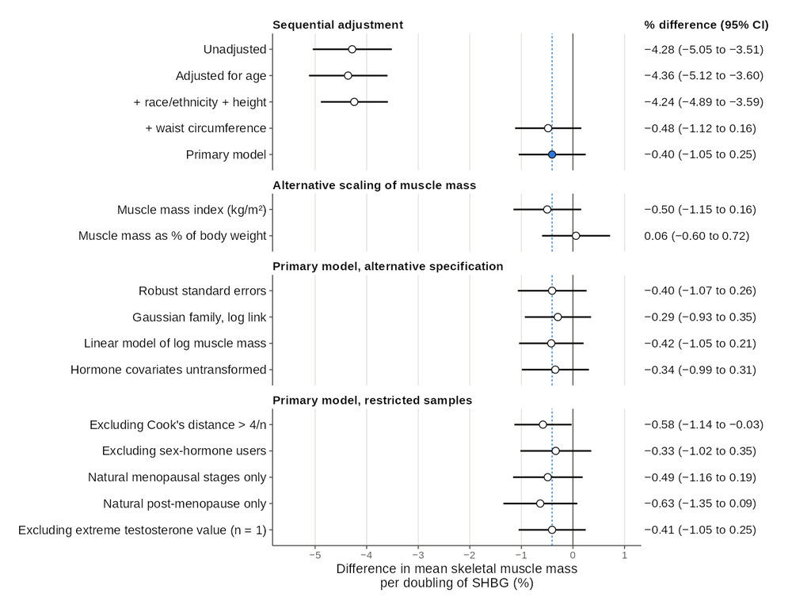

Percent difference in mean skeletal muscle mass per doubling of SHBG, with 95% confidence intervals, under sequential adjustment, alternative scaling of muscle mass, alternative specifications and restricted samples. The filled point and the dotted line mark the primary model.

- **Scaling of muscle mass.** As an index (kg/m², without height as a covariate) the estimate is −0.50% (95% CI −1.15 to 0.16); as a percentage of body weight, 0.06% (95% CI −0.60 to 0.72).
- **Specification.** Robust standard errors, a Gaussian model, a log-linear model and untransformed hormone covariates give estimates between −0.42% and −0.29%.
- **Sample.** Restrictions give estimates between −0.63% and −0.33%. The only confidence interval that excludes zero is the one obtained without the 69 observations with a Cook’s distance above 4/n: −0.58% (95% CI −1.14 to −0.03), P = 0.040. A small association cannot be ruled out.

## All specifications

```r
kt(data.frame(ID = sen$id, Group = sub("^[A-G]\\. ", "", sen$group), Specification = ufix(sen$specification), n = fmt(sen$n, 0),
              `Ratio of means (95% CI)` = paste0(fmt(sen$ratio, 3), " (", ci(sen$lcl, sen$ucl, 3), ")"),
              `Difference, % (95% CI)` = paste0(fmt(sen$pct_difference, 2), " (", ci(pct(sen$lcl), pct(sen$ucl)), ")"),
              `P value` = pval(sen$p), check.names = FALSE), align = "lllrrrr")
```

| ID | Group | Specification | n | Ratio of means (95% CI) | Difference, % (95% CI) | P value |
| --- | --- | --- | --- | --- | --- | --- |
| A1 | Sequential adjustment | Unadjusted | 1,693 | 0.957 (0.950 to 0.965) | −4.28 (−5.05 to −3.51) | <0.001 |
| A2 | Sequential adjustment | Adjusted for age | 1,693 | 0.956 (0.949 to 0.964) | −4.36 (−5.12 to −3.60) | <0.001 |
| A3 | Sequential adjustment | Adjusted for age, race/ethnicity and height | 1,693 | 0.958 (0.951 to 0.964) | −4.24 (−4.89 to −3.59) | <0.001 |
| A4 | Sequential adjustment | Adjusted for age, race/ethnicity, height and waist circumference | 1,693 | 0.995 (0.989 to 1.002) | −0.48 (−1.12 to 0.16) | 0.143 |
| A5 | Sequential adjustment | Primary model | 1,693 | 0.996 (0.989 to 1.002) | −0.40 (−1.05 to 0.25) | 0.223 |
| B1 | One covariate removed from the primary model | Primary model without waist circumference | 1,693 | 0.965 (0.959 to 0.971) | −3.50 (−4.14 to −2.86) | <0.001 |
| B2 | One covariate removed from the primary model | Primary model without height | 1,693 | 0.999 (0.992 to 1.007) | −0.08 (−0.82 to 0.66) | 0.827 |
| B3 | One covariate removed from the primary model | Primary model without race/ethnicity | 1,693 | 0.995 (0.988 to 1.001) | −0.53 (−1.18 to 0.11) | 0.105 |
| B4 | One covariate removed from the primary model | Primary model without age | 1,693 | 0.996 (0.990 to 1.003) | −0.39 (−1.03 to 0.27) | 0.244 |
| B5 | One covariate removed from the primary model | Primary model without menopausal status | 1,693 | 0.996 (0.989 to 1.002) | −0.44 (−1.09 to 0.21) | 0.180 |
| B6 | One covariate removed from the primary model | Primary model without the five hormone covariates | 1,693 | 0.996 (0.990 to 1.002) | −0.41 (−1.05 to 0.22) | 0.203 |
| B7 | One covariate removed from the primary model | Primary model without activity limitation | 1,693 | 0.996 (0.989 to 1.002) | −0.44 (−1.08 to 0.22) | 0.189 |
| B8 | One covariate removed from the primary model | Primary model without exercise | 1,693 | 0.995 (0.989 to 1.002) | −0.45 (−1.10 to 0.21) | 0.179 |
| C1 | Other measures of body size | Body mass index in place of height and waist circumference | 1,693 | 0.995 (0.988 to 1.002) | −0.54 (−1.25 to 0.18) | 0.139 |
| C2 | Other measures of body size | Weight in place of waist circumference | 1,693 | 0.997 (0.991 to 1.003) | −0.31 (−0.89 to 0.28) | 0.305 |
| C3 | Other measures of body size | Fat mass in place of waist circumference | 1,693 | 0.975 (0.968 to 0.982) | −2.49 (−3.16 to −1.82) | <0.001 |
| C4 | Other measures of body size | Primary model + percent body fat | 1,693 | 0.998 (0.993 to 1.002) | −0.24 (−0.70 to 0.23) | 0.323 |
| C5 | Other measures of body size | Primary model + body mass index | 1,693 | 0.995 (0.989 to 1.001) | −0.53 (−1.12 to 0.07) | 0.082 |
| C6 | Other measures of body size | Primary model + fat mass | 1,693 | 0.998 (0.992 to 1.005) | −0.17 (−0.79 to 0.46) | 0.593 |
| C7 | Other measures of body size | Covariates of the initial model | 1,693 | 0.964 (0.956 to 0.972) | −3.56 (−4.35 to −2.76) | <0.001 |
| D1 | Alternative scaling of muscle mass | Skeletal muscle mass index (kg/m²) | 1,693 | 0.995 (0.988 to 1.002) | −0.50 (−1.15 to 0.16) | 0.138 |
| D2 | Alternative scaling of muscle mass | Skeletal muscle mass as % of body weight | 1,693 | 1.001 (0.994 to 1.007) | 0.06 (−0.60 to 0.72) | 0.862 |
| E1 | Model specification | Primary model, robust (HC3) standard errors | 1,693 | 0.996 (0.989 to 1.003) | −0.40 (−1.07 to 0.26) | 0.235 |
| E2 | Model specification | Gaussian family, log link | 1,693 | 0.997 (0.991 to 1.004) | −0.29 (−0.93 to 0.35) | 0.371 |
| E3 | Model specification | Linear regression of log skeletal muscle mass | 1,693 | 0.996 (0.990 to 1.002) | −0.42 (−1.05 to 0.21) | 0.188 |
| E4 | Model specification | Hormone covariates untransformed | 1,693 | 0.997 (0.990 to 1.003) | −0.34 (−0.99 to 0.31) | 0.302 |
| F1 | Sample restrictions | Excluding observations with Cook’s distance > 4/n | 1,624 | 0.994 (0.989 to 1.000) | −0.58 (−1.14 to −0.03) | 0.040 |
| F2 | Sample restrictions | Excluding users of exogenous sex hormones | 1,546 | 0.997 (0.990 to 1.004) | −0.33 (−1.02 to 0.35) | 0.340 |
| F3 | Sample restrictions | Natural menopausal stages only | 1,525 | 0.995 (0.988 to 1.002) | −0.49 (−1.16 to 0.19) | 0.156 |
| F4 | Sample restrictions | Natural post-menopause only | 1,295 | 0.994 (0.987 to 1.001) | −0.63 (−1.35 to 0.09) | 0.084 |
| F5 | Sample restrictions | Excluding the participant with the extreme testosterone value | 1,692 | 0.996 (0.989 to 1.002) | −0.41 (−1.05 to 0.25) | 0.223 |

Per doubling of SHBG. In D1 height is not a covariate. In C7 the covariates are those of the initial model.

## Shape of the association

```r
kt(data.frame(Model = NL$model, `Term tested` = NL$term_tested, `AIC, log2(SHBG)` = fmt(NL$aic_log2, 1), `AIC, SHBG linear` = fmt(NL$aic_linear, 1),
              `AIC, spline (3 df)` = fmt(NL$aic_spline_3df, 1),
              `Test against the spline` = paste0("F = ", fmt(NL$F_nonlinearity, 2), " (df = ", NL$df1, " and ", fmt(NL$df2, 0), "); ", ptext(NL$p_nonlinearity)),
              `Ratio per 10 nmol/L, SHBG linear (95% CI)` = paste0(fmt(NL$ratio_per_10, 3), " (", ci(NL$lcl_per_10, NL$ucl_per_10, 3), ")"),
              check.names = FALSE), align = "llrrrlr")
```

| Model | Term tested | AIC, log2(SHBG) | AIC, SHBG linear | AIC, spline (3 df) | Test against the spline | Ratio per 10 nmol/L, SHBG linear (95% CI) |
| --- | --- | --- | --- | --- | --- | --- |
| Primary model | log2(SHBG) | 7,309.8 | 7,311.3 | 7,309.0 | F = 2.25 (df = 2 and 1,669); P = 0.106 | 1.000 (0.998 to 1.002) |
| Covariates of the initial model | SHBG, linear | 8,365.8 | 8,383.2 | 8,363.7 | F = 11.21 (df = 2 and 1,673); P < 0.001 | 0.989 (0.987 to 0.992) |

In the primary model there is no evidence of departure from linearity on the logarithmic scale, and SHBG entered as an untransformed linear term leads to the same conclusion (P = 0.771). With the covariates of the initial model a linear term does not describe the association: the slope is steeper at low concentrations and flattens at high ones, and the logarithm fits better. This is one of the reasons for the logarithmic scale of the primary model.

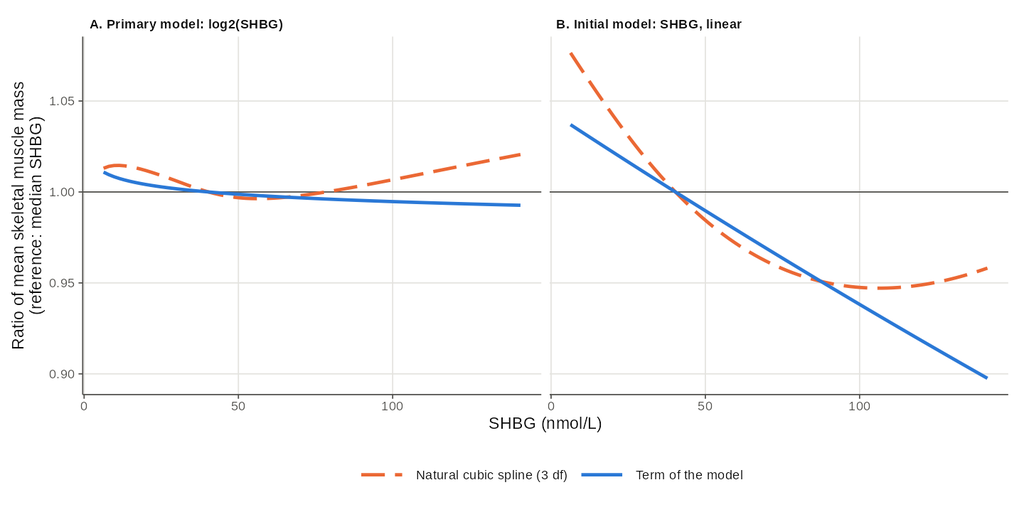

Ratio of mean skeletal muscle mass relative to the median SHBG. (A) Primary model: the term for log2(SHBG) and a natural cubic spline of log2(SHBG). (B) Initial model: the linear term for SHBG and a natural cubic spline of SHBG.

## Initial model

```r
ti <- tab("tableS_submitted_model")
kt(data.frame(Variable = term_label(ti$term, ti$label),
              `Ratio of means (95% CI)` = paste0(fmt(ti$ratio, 3), " (", ci(ti$lcl, ti$ucl, 3), ")"),
              `Difference in mean, %` = fmt(ti$pct_difference, 2), `P value` = pval(ti$p), check.names = FALSE), align = "lrrr")
```

| Variable | Ratio of means (95% CI) | Difference in mean, % | P value |
| --- | --- | --- | --- |
| SHBG, per 10 nmol/L | 0.989 (0.987 to 0.992) | −1.06 | <0.001 |
| Testosterone, per 10 ng/dL | 1.003 (1.002 to 1.005) | 0.35 | <0.001 |
| Estradiol, per 10 pg/mL | 1.000 (0.998 to 1.002) | −0.01 | 0.927 |
| FSH, per 10 mIU/mL | 0.993 (0.991 to 0.994) | −0.72 | <0.001 |
| DHEA-S, per 50 µg/dL | 0.993 (0.988 to 0.998) | −0.70 | 0.005 |
| TSH, per 1 µIU/mL | 0.999 (0.997 to 1.002) | −0.07 | 0.606 |
| Age, per 1 year | 0.994 (0.991 to 0.997) | −0.61 | <0.001 |
| Body fat, per 5 percentage points | 0.998 (0.994 to 1.003) | −0.19 | 0.395 |
| Menopausal status: Premenopause | 0.865 (0.761 to 0.984) | −13.50 | 0.027 |
| Menopausal status: Early perimenopause | 0.987 (0.957 to 1.018) | −1.28 | 0.416 |
| Menopausal status: Late perimenopause | 1.038 (1.007 to 1.070) | 3.81 | 0.016 |
| Menopausal status: Surgical menopause (BSO) | 1.047 (1.016 to 1.080) | 4.75 | 0.003 |
| Menopausal status: Undetermined (hormone therapy) | 1.016 (0.959 to 1.075) | 1.58 | 0.591 |
| Menopausal status: Undetermined (hysterectomy) | 1.032 (0.988 to 1.078) | 3.17 | 0.162 |
| Vigorous activities: Limited a little | 0.997 (0.981 to 1.013) | −0.27 | 0.743 |
| Vigorous activities: Limited a lot | 1.032 (1.012 to 1.052) | 3.16 | 0.002 |
| Exercise for health: Yes | 1.016 (0.999 to 1.033) | 1.55 | 0.068 |

The model specified first, with SHBG and the hormones on their original scale and percent body fat as the only measure of body composition (definition and reasons for its revision). It gives −1.06% per 10 nmol/L of SHBG (95% CI −1.34 to −0.79). One participant had a testosterone concentration of 1,573 ng/dL (54.5 nmol/L), with a leverage of 0.77 and a Cook’s distance of 6.1 in this model. In the primary model, in which the hormones are on the logarithmic scale, excluding her gives −0.41% (95% CI −1.05 to 0.25).

## SHBG as the dependent variable

```r
so <- tab("tableS_shbg_outcome")
lab_of <- function(d) { l <- c(tab("table2_primary_model")$label, ti$label); names(l) <- c(tab("table2_primary_model")$term, ti$term); unname(l[d$term]) }
show_so <- function(m) { d <- so[so$model == m, ]
  kt(data.frame(Variable = term_label(d$term, lab_of(d)), `Ratio of mean SHBG (95% CI)` = paste0(fmt(d$ratio, 3), " (", ci(d$lcl, d$ucl, 3), ")"),
                `P value` = pval(d$p), check.names = FALSE), align = "lrr") }
sp <- R$shbg_outcome$primary
sjt <- rows(R$shbg_outcome$joint)
sjf <- function(term) paste0("F = ", fmt(sjt$F[sjt$term == term], 2), " (df = ", sjt$df[sjt$term == term], " and ", fmt(sjt$df_residual[1], 0), "; ", ptext(sjt$p[sjt$term == term]), ")")
stopifnot(sp$smm$p > 0.05, sp$waist_cm$p < 0.001, R$shbg_outcome$submitted_smm$p < 0.001,
          sp[["log2(estradiol)"]]$p < 0.001, sp[["log2(estradiol)"]]$ratio > 1, sp[["log2(dheas)"]]$p < 0.001, sp[["log2(dheas)"]]$ratio < 1,
          sjt$p[sjt$term == "race"] < 0.001, sjt$p[sjt$term == "status"] < 0.05)
```

**Covariates of the primary model (Table 3 of the manuscript)**

```r
show_so("Covariates of the primary model")
```

| Variable | Ratio of mean SHBG (95% CI) | P value |
| --- | --- | --- |
| Skeletal muscle mass, per 1 kg | 0.999 (0.988 to 1.010) | 0.881 |
| Testosterone, per doubling | 0.965 (0.931 to 1.001) | 0.056 |
| FSH, per doubling | 1.027 (0.990 to 1.065) | 0.158 |
| Estradiol, per doubling | 1.138 (1.102 to 1.175) | <0.001 |
| TSH, per doubling | 0.975 (0.950 to 1.001) | 0.057 |
| DHEA-S, per doubling | 0.894 (0.867 to 0.921) | <0.001 |
| Age, per 1 year | 0.994 (0.984 to 1.004) | 0.223 |
| Height, per 5 cm | 1.022 (0.998 to 1.046) | 0.072 |
| Waist circumference, per 5 cm | 0.908 (0.897 to 0.918) | <0.001 |
| Race/ethnicity: Black | 1.090 (1.024 to 1.159) | 0.007 |
| Race/ethnicity: Chinese | 0.798 (0.729 to 0.873) | <0.001 |
| Race/ethnicity: Japanese | 0.933 (0.854 to 1.020) | 0.126 |
| Menopausal status: Premenopause | 0.907 (0.574 to 1.435) | 0.678 |
| Menopausal status: Early perimenopause | 0.939 (0.837 to 1.052) | 0.278 |
| Menopausal status: Late perimenopause | 0.857 (0.770 to 0.954) | 0.005 |
| Menopausal status: Surgical menopause (BSO) | 0.998 (0.897 to 1.111) | 0.974 |
| Menopausal status: Undetermined (hormone therapy) | 1.077 (0.880 to 1.319) | 0.470 |
| Menopausal status: Undetermined (hysterectomy) | 0.817 (0.700 to 0.954) | 0.011 |
| Vigorous activities: Limited a little | 0.992 (0.937 to 1.051) | 0.792 |
| Vigorous activities: Limited a lot | 1.030 (0.961 to 1.104) | 0.404 |
| Exercise for health: Yes | 0.972 (0.916 to 1.031) | 0.338 |

Joint $F$ tests: race/ethnicity, F = 11.70 (df = 3 and 1,671; P < 0.001); menopausal status, F = 2.42 (df = 6 and 1,671; P = 0.025); activity limitation, F = 0.65 (df = 2 and 1,671; P = 0.523). The model explains 26.8% of the deviance.

**Covariates of the initial model**

```r
show_so("Covariates of the initial model")
```

| Variable | Ratio of mean SHBG (95% CI) | P value |
| --- | --- | --- |
| Skeletal muscle mass, per 1 kg | 0.968 (0.959 to 0.976) | <0.001 |
| Testosterone, per 10 ng/dL | 0.999 (0.993 to 1.005) | 0.739 |
| FSH, per 10 mIU/mL | 1.014 (1.008 to 1.019) | <0.001 |
| Estradiol, per 10 pg/mL | 1.033 (1.025 to 1.040) | <0.001 |
| TSH, per 1 µIU/mL | 0.984 (0.975 to 0.994) | <0.001 |
| DHEA-S, per 50 µg/dL | 0.939 (0.922 to 0.956) | <0.001 |
| Age, per 1 year | 0.989 (0.979 to 0.999) | 0.040 |
| Body fat, per 5 percentage points | 0.918 (0.903 to 0.933) | <0.001 |
| Menopausal status: Premenopause | 1.052 (0.651 to 1.699) | 0.835 |
| Menopausal status: Early perimenopause | 0.955 (0.851 to 1.073) | 0.437 |
| Menopausal status: Late perimenopause | 0.892 (0.797 to 0.999) | 0.049 |
| Menopausal status: Surgical menopause (BSO) | 1.011 (0.903 to 1.132) | 0.851 |
| Menopausal status: Undetermined (hormone therapy) | 1.146 (0.926 to 1.417) | 0.210 |
| Menopausal status: Undetermined (hysterectomy) | 0.873 (0.742 to 1.027) | 0.102 |
| Vigorous activities: Limited a little | 0.949 (0.894 to 1.008) | 0.088 |
| Vigorous activities: Limited a lot | 0.983 (0.915 to 1.057) | 0.643 |
| Exercise for health: Yes | 1.001 (0.941 to 1.065) | 0.970 |

Complementary gamma log-link model with SHBG as the dependent variable. The concentration of SHBG responds to adiposity and to other hormones, so it is natural to read the association with SHBG as the variable to be explained. Read in that direction the conclusion is the same. With the covariates of the primary model, skeletal muscle mass is not associated with SHBG (ratio per kilogram 0.999; 95% CI 0.988 to 1.010), whereas mean SHBG is 9.2% lower for each 5 cm of waist circumference, 13.8% higher for each doubling of estradiol and 10.6% lower for each doubling of DHEA-S, and differs by race/ethnicity and menopausal status. With the covariates of the initial model, each additional kilogram of skeletal muscle mass was associated with 3.2% lower SHBG. The primary analysis keeps skeletal muscle mass as the dependent variable because that is how the question is posed in the literature; the design is cross-sectional and neither model identifies a direction of effect.

## Code behind this page

The code of each table is folded above it (*Code*), and the *Code* menu at the top of the page shows or hides all of it. That code only reads the output of the pipeline. The numbers are computed by the scripts below, shown as they are in [`analysis/`](https://github.com/AmaruSimonAgueroJimenez/SWAN/tree/main/analysis) and not run here. All the scripts of the pipeline are on the page Reproducibility.

**analysis/config.R · paths, reporting units, reference categories, expected values of the models**

```r
# =============================================================================
# Configuration for the SHBG / skeletal muscle mass analysis (PLOS ONE revision)
# Single source of truth for paths, units and analysis settings.
# All scripts are run from the repository root (see analysis/run_all.R).
# =============================================================================

CFG <- list(
  # ---- paths ---------------------------------------------------------------
  data_file = file.path("ICPSR_32961", "DS0001", "32961-0001-Data.dta"),
  out_dir   = file.path("analysis", "output"),

  # ---- inference -----------------------------------------------------------
  conf_level = 0.95,
  seed       = 20261117L,   # only used for the randomised quantile residuals

  # ---- reporting units -----------------------------------------------------
  # Associations are reported as ratios of means per `unit` of each covariate.
  unit = c(
    shbg         = 10,   # nmol/L
    testosterone = 10,   # ng/dL
    fsh          = 10,   # mIU/mL
    estradiol    = 10,   # pg/mL
    tsh          = 1,    # uIU/mL
    dheas        = 50,   # ug/dL
    age          = 1,    # years
    pbf          = 5,    # percentage points
    bmi          = 1,    # kg/m2
    height_cm    = 5,    # cm
    weight_kg    = 5,    # kg
    fat_mass_kg  = 5,    # kg
    waist_cm     = 5,    # cm
    smm          = 1     # kg (used when SHBG is the dependent variable)
  ),

  # ---- SI conversion (dataset unit x factor = SI unit) ------------------------
  # Factors follow from the molar masses (4 significant digits): testosterone 288.42 g/mol,
  # estradiol 272.38 g/mol, DHEA-S 368.49 g/mol. FSH (mIU/mL = IU/L) and
  # TSH (uIU/mL = mIU/L) are numerically identical in SI units.
  si = list(
    testosterone = list(factor = 0.03467, unit = "nmol/L", digits = 2L),
    estradiol    = list(factor = 3.671,  unit = "pmol/L", digits = 1L),
    dheas        = list(factor = 0.02714, unit = "umol/L", digits = 2L)
  ),

  # ---- reference categories --------------------------------------------------
  ref_status   = "Natural post-menopause",
  ref_activity = "Not limited",
  ref_exercise = "No",
  ref_race     = "White",

  # ---- regression tests -------------------------------------------------------
  # Primary model (revised in November 2026): gamma log-link model of skeletal
  # muscle mass on log2(SHBG), adjusted for age, height, waist circumference,
  # race/ethnicity, menopausal status, log2 hormones, activity limitation and
  # exercise. The pipeline stops if these values are not reproduced.
  expected_primary = list(n = 1693L, aic = 7309.813, beta_log2_shbg = -0.004054),
  # Model of the first submission (SKELMMM10 in docs/exploratory.qmd and
  # docs/resultados_modelos_SKELMMM.xlsx), now a sensitivity analysis.
  expected_submitted = list(n = 1693L, aic = 8383.171, beta_shbg = -0.001069)
)
```

**analysis/R/functions.R · definition of the primary and initial models, model fitting, ratios of means, standardized means**

```r
# =============================================================================
# Helper functions shared by every analysis script
# =============================================================================

suppressPackageStartupMessages({
  library(dplyr)
  library(tidyr)
})

# ---- model fitting ----------------------------------------------------------
# All ratio-scale models go through this single function so that the family and
# link are guaranteed to be identical across the primary and sensitivity models.
fit_gamma_log <- function(formula, data) {
  m <- glm(formula, data = data, family = Gamma(link = "log"))
  stopifnot(m$converged)
  m
}

# Hormone covariates (all strictly positive concentrations).
HORMONES <- c("testosterone", "fsh", "estradiol", "tsh", "dheas")

# Primary model (revised in November 2026). SHBG and the hormone covariates enter
# on the log2 scale; body size is represented by height and waist circumference.
PRIMARY_EXPOSURE   <- "log2(shbg)"
PRIMARY_COVARIATES <- c(paste0("log2(", HORMONES, ")"), "age", "height_cm", "waist_cm", "race",
                        "status", "activity_limit", "exercise")

# Initial model: the model of the first submission (SKELMMM10; only the reference level of
# menopausal status differs, which does not change the fit). Kept as a sensitivity analysis
# and called "initial model" in every table and figure.
SUBMITTED_EXPOSURE   <- "shbg"
SUBMITTED_COVARIATES <- c(HORMONES, "age", "pbf", "status", "activity_limit", "exercise")

# Variables that must be complete for a woman to be analysed: those of the primary
# model and of the submitted model, so that every model uses the same sample.
MODEL_VARIABLES <- c("smm", "shbg", HORMONES, "age", "height_cm", "waist_cm", "race",
                     "status", "activity_limit", "exercise", "pbf")

make_formula <- function(outcome, exposure, covariates) {
  reformulate(c(exposure, covariates), response = outcome)
}

# ---- extraction -------------------------------------------------------------
# Ratio of means (exp(beta * unit)) with a Wald interval based on the
# t distribution with the residual degrees of freedom, i.e. the same reference
# distribution that summary.glm() uses for families with estimated dispersion.
ratio_for_term <- function(model, term, unit, conf_level, vcov_matrix = NULL) {
  stopifnot(term %in% names(coef(model)))
  beta <- unname(coef(model)[term])
  V    <- if (is.null(vcov_matrix)) vcov(model) else vcov_matrix
  se   <- sqrt(V[term, term])
  df   <- model$df.residual
  crit <- qt(1 - (1 - conf_level) / 2, df)
  tval <- beta / se
  data.frame(
    term     = term,
    unit     = unit,
    beta     = beta,
    se       = se,
    ratio    = exp(unit * beta),
    lcl      = exp(unit * (beta - crit * se)),
    ucl      = exp(unit * (beta + crit * se)),
    p        = 2 * pt(abs(tval), df, lower.tail = FALSE),
    n        = nobs(model),
    stringsAsFactors = FALSE
  )
}

# Marginally standardised mean of a log-link model across values of SHBG, with
# delta-method confidence limits. Every participant is assigned SHBG = x and the
# predictions are averaged over the observed covariates:
#   m(x) = mean_i exp(X_i(x) b);   dm/db = mean_i exp(X_i(x) b) X_i(x)
marginal_curve <- function(model, data, grid, conf_level) {
  stopifnot(family(model)$link == "log", "shbg" %in% all.vars(formula(model)))
  tt <- delete.response(terms(model)); V <- vcov(model); b <- coef(model)
  crit <- qt(1 - (1 - conf_level) / 2, model$df.residual)
  do.call(rbind, lapply(grid, function(x) {
    nd <- data; nd$shbg <- x
    X  <- model.matrix(tt, nd, xlev = model$xlevels)
    mu <- as.vector(exp(X %*% b))
    g  <- colMeans(mu * X)
    se <- sqrt(as.numeric(t(g) %*% V %*% g))
    data.frame(shbg = x, mean = mean(mu), lcl = mean(mu) - crit * se, ucl = mean(mu) + crit * se)
  }))
}

# Full regression output on the scale of the linear predictor
full_output <- function(model, label) {
  co <- summary(model)$coefficients
  data.frame(model = label, term = rownames(co), beta = co[, "Estimate"], se = co[, "Std. Error"],
             t = co[, "t value"], p = co[, "Pr(>|t|)"], row.names = NULL, stringsAsFactors = FALSE)
}
fit_measures <- function(model, label) {
  data.frame(model = label, n = nobs(model), residual_df = model$df.residual,
             dispersion = summary(model)$dispersion, null_deviance = model$null.deviance,
             residual_deviance = deviance(model), log_likelihood = as.numeric(logLik(model)),
             aic = AIC(model), bic = BIC(model), stringsAsFactors = FALSE)
}

# percent difference implied by a ratio
pct <- function(ratio) 100 * (ratio - 1)

# ---- formatting -------------------------------------------------------------
fmt_num <- function(x, digits) formatC(x, format = "f", digits = digits, big.mark = ",")

fmt_p <- function(p) {
  ifelse(is.na(p), NA_character_,
         ifelse(p < 0.001, "<0.001", formatC(p, format = "f", digits = 3)))
}

fmt_ci <- function(est, lcl, ucl, digits) {
  sprintf("%s (%s to %s)", fmt_num(est, digits), fmt_num(lcl, digits), fmt_num(ucl, digits))
}

mean_sd <- function(x, digits = 1) {
  stopifnot(!anyNA(x))
  sprintf("%s (%s)", fmt_num(mean(x), digits), fmt_num(sd(x), digits))
}

median_iqr <- function(x, digits = 1) {
  stopifnot(!anyNA(x))
  q <- quantile(x, c(0.25, 0.5, 0.75), names = FALSE)
  sprintf("%s (%s to %s)", fmt_num(q[2], digits), fmt_num(q[1], digits), fmt_num(q[3], digits))
}

n_pct <- function(x, level, digits = 1) {
  stopifnot(!anyNA(x))
  k <- sum(x == level)
  sprintf("%s (%s)", fmt_num(k, 0), fmt_num(100 * k / length(x), digits))
}

# ---- output -----------------------------------------------------------------
write_table <- function(df, name, out_dir) {
  path <- file.path(out_dir, "tables", paste0(name, ".csv"))
  write.csv(df, path, row.names = FALSE, fileEncoding = "UTF-8")
  message("  wrote ", path)
  invisible(path)
}
```

**analysis/R/03_primary_model.R · primary model, initial model, adjusted means, diagnostics of both**

```r
# =============================================================================
# 03 - Primary model: skeletal muscle mass ~ log2(SHBG) + covariates
#      Gamma family, log link. Covariates: age, height, waist circumference,
#      race/ethnicity, menopausal status, log2 of testosterone, estradiol, FSH,
#      DHEA-S and TSH, limitation of vigorous activities and exercise.
#      The model of the first submission (SKELMMM10) is also fitted here and kept
#      as a sensitivity analysis.
#   table2_primary_model.csv     ratios of means, 95% CI and P values
#   tableS_submitted_model.csv   the same for the model of the first submission
#   tableS_primary_joint_tests.csv  joint F tests of the terms of the primary model
#   tableS_predicted_smm.csv     adjusted mean skeletal muscle mass at selected SHBG values
#   tableS_diagnostics.csv       dispersion, collinearity, influence, link test
#   tableS_vif.csv               adjusted generalised variance inflation factors
#   tableS_diagnostics_initial.csv  the same diagnostics for the initial model
# =============================================================================
source("analysis/config.R"); source("analysis/R/functions.R")
suppressPackageStartupMessages(library(car))
analytic <- readRDS(file.path(CFG$out_dir, "data", "analytic.rds"))
cl <- CFG$conf_level

f_primary <- make_formula("smm", PRIMARY_EXPOSURE, PRIMARY_COVARIATES)
m_primary <- fit_gamma_log(f_primary, analytic)

# ---- regression tests -----------------------------------------------------------
exp_ <- CFG$expected_primary
stopifnot(nobs(m_primary) == exp_$n,
          abs(AIC(m_primary) - exp_$aic) < 1e-3,
          abs(coef(m_primary)[["log2(shbg)"]] - exp_$beta_log2_shbg) < 1e-6)
message("Primary model reproduces the expected n, AIC and SHBG coefficient.")

f_submitted <- make_formula("smm", SUBMITTED_EXPOSURE, SUBMITTED_COVARIATES)
m_submitted <- fit_gamma_log(f_submitted, analytic)
exs <- CFG$expected_submitted
stopifnot(nobs(m_submitted) == exs$n,
          abs(AIC(m_submitted) - exs$aic) < 1e-3,
          abs(coef(m_submitted)[["shbg"]] - exs$beta_shbg) < 1e-6)
message("The model of the first submission is reproduced (n, AIC and SHBG coefficient).")

# ---- tables of ratios of means ----------------------------------------------------
cat_labels <- c(
  "raceBlack" = "  Black", "raceChinese" = "  Chinese", "raceJapanese" = "  Japanese",
  "statusPremenopause" = "  Premenopause",
  "statusEarly perimenopause" = "  Early perimenopause",
  "statusLate perimenopause" = "  Late perimenopause",
  "statusSurgical menopause (BSO)" = "  Surgical menopause (BSO)",
  "statusUndetermined (hormone therapy)" = "  Undetermined (hormone therapy)",
  "statusUndetermined (hysterectomy)" = "  Undetermined (hysterectomy)",
  "activity_limitLimited a little" = "  Limited a little",
  "activity_limitLimited a lot" = "  Limited a lot",
  "exerciseYes" = "  Yes")
labels_primary <- c(
  "log2(shbg)" = "SHBG, per doubling",
  "log2(testosterone)" = "Testosterone, per doubling",
  "log2(estradiol)" = "Estradiol, per doubling",
  "log2(fsh)" = "FSH, per doubling",
  "log2(dheas)" = "DHEA-S, per doubling",
  "log2(tsh)" = "TSH, per doubling",
  age = "Age, per 1 year",
  height_cm = "Height, per 5 cm",
  waist_cm = "Waist circumference, per 5 cm",
  cat_labels)
labels_submitted <- c(
  shbg = "SHBG, per 10 nmol/L",
  testosterone = "Testosterone, per 10 ng/dL",
  estradiol = "Estradiol, per 10 pg/mL",
  fsh = "FSH, per 10 mIU/mL",
  dheas = "DHEA-S, per 50 ug/dL",
  tsh = "TSH, per 1 uIU/mL",
  age = "Age, per 1 year",
  pbf = "Body fat, per 5 percentage points",
  cat_labels[!grepl("^race", names(cat_labels))])

# reporting unit of a term: 1 for log2 terms (a doubling) and for indicator variables
unit_of <- function(term) if (term %in% names(CFG$unit)) CFG$unit[[term]] else 1
ratio_table <- function(model, labels) {
  stopifnot(setequal(names(labels), setdiff(names(coef(model)), "(Intercept)")))
  tab <- do.call(rbind, lapply(names(labels), function(tm) ratio_for_term(model, tm, unit_of(tm), cl)))
  tab$label <- unname(labels[tab$term]); tab$pct_difference <- pct(tab$ratio)
  tab[, c("label", "term", "unit", "beta", "se", "ratio", "lcl", "ucl", "pct_difference", "p", "n")]
}
tab2 <- ratio_table(m_primary, labels_primary)
write_table(tab2, "table2_primary_model", CFG$out_dir)
tab_sub <- ratio_table(m_submitted, labels_submitted)
write_table(tab_sub, "tableS_submitted_model", CFG$out_dir)

# joint (multi-degree-of-freedom) tests of the terms of the primary model
joint <- car::Anova(m_primary, type = 2, test.statistic = "F")
joint_tab <- data.frame(term = rownames(joint), F = joint$F, df = joint$Df, df_residual = m_primary$df.residual, p = joint$`Pr(>F)`)
write_table(joint_tab, "tableS_primary_joint_tests", CFG$out_dir)

# ---- adjusted means at selected SHBG concentrations --------------------------
# Marginal standardisation: every participant is assigned the same SHBG value,
# predictions are averaged over the observed covariate distribution.
q <- quantile(analytic$shbg, c(0.10, 0.25, 0.50, 0.75, 0.90), names = FALSE)
pred_tab <- cbind(shbg_percentile = c(10, 25, 50, 75, 90), marginal_curve(m_primary, analytic, q, cl))
names(pred_tab) <- c("shbg_percentile", "shbg_nmol_L", "adjusted_mean_smm_kg", "lcl", "ucl")
pred_tab$difference_vs_p25_kg <- pred_tab$adjusted_mean_smm_kg - pred_tab$adjusted_mean_smm_kg[2]
write_table(pred_tab, "tableS_predicted_smm", CFG$out_dir)

# average change in skeletal muscle mass (kg) for a doubling of SHBG
ame_doubling <- mean(predict(m_primary, transform(analytic, shbg = 2 * shbg), type = "response") -
                     predict(m_primary, analytic, type = "response"))

# ---- diagnostics --------------------------------------------------------------
# The same quantities are computed for the primary and for the initial model.
diagnostics_of <- function(model, formula, data) {
  gv <- car::vif(model)                            # generalised VIF
  vif_adj <- gv[, "GVIF^(1/(2*Df))"]^2             # comparable to an ordinary VIF
  cd <- cooks.distance(model)
  # Pregibon link test: the squared linear predictor should add nothing
  eta <- predict(model, type = "link")
  m_link <- fit_gamma_log(update(formula, . ~ . + I(eta^2)), cbind(data, eta = eta))
  fitted_ <- fitted(model)
  list(vif_adj = vif_adj, cooks = cd,
       table = data.frame(
         quantity = c("Dispersion parameter", "Residual deviance", "Residual df",
                      "Deviance explained (1 - deviance/null deviance)",
                      "RMSE, kg", "Correlation observed vs fitted",
                      "Largest adjusted GVIF", "Term with largest adjusted GVIF",
                      "Observations with Cook's distance > 4/n", "Largest Cook's distance", "Largest leverage",
                      "Link test P (squared linear predictor)"),
         value = c(signif(summary(model)$dispersion, 4), round(deviance(model), 3), model$df.residual,
                   round(1 - deviance(model) / model$null.deviance, 4),
                   round(sqrt(mean((data$smm - fitted_)^2)), 3), round(cor(data$smm, fitted_), 3),
                   round(max(vif_adj), 2), names(which.max(vif_adj)),
                   sum(cd > 4 / nobs(model)), signif(max(cd), 3), signif(max(hatvalues(model)), 3),
                   signif(summary(m_link)$coefficients["I(eta^2)", "Pr(>|t|)"], 3))))
}
phi <- summary(m_primary)$dispersion
dg_primary <- diagnostics_of(m_primary, f_primary, analytic)
dg_initial <- diagnostics_of(m_submitted, f_submitted, analytic)
vif_adj <- dg_primary$vif_adj
cd <- dg_primary$cooks
diag_tab <- rbind(dg_primary$table,
                  data.frame(quantity = "Average change in SMM for a doubling of SHBG, kg", value = round(ame_doubling, 3)))
write_table(diag_tab, "tableS_diagnostics", CFG$out_dir)
write_table(dg_initial$table, "tableS_diagnostics_initial", CFG$out_dir)
write_table(data.frame(term = names(vif_adj), adjusted_gvif = round(vif_adj, 2)), "tableS_vif", CFG$out_dir)

saveRDS(list(model = m_primary, formula = f_primary, table2 = tab2, pred = pred_tab, ame_doubling = ame_doubling,
             joint = joint_tab, phi = phi, cooks = cd,
             submitted = m_submitted, formula_submitted = f_submitted, table_submitted = tab_sub,
             cooks_submitted = cooks.distance(m_submitted)),
        file.path(CFG$out_dir, "data", "primary_model.rds"))
print(tab2[, c("label", "ratio", "lcl", "ucl", "p")], digits = 4, row.names = FALSE)
print(joint_tab, digits = 4, row.names = FALSE)
print(pred_tab, digits = 4, row.names = FALSE)
print(diag_tab, row.names = FALSE)
```

**analysis/R/04_sensitivity.R · sensitivity models, shape of the association, full regression output**

```r
# =============================================================================
# 04 - Sensitivity analyses for the association between SHBG and skeletal
#      muscle mass. Every estimate is the ratio of means per doubling of SHBG
#      (coefficient of log2(SHBG)) from a gamma log-link model unless stated.
#   tableS_sensitivity.csv              all specifications (groups A to F)
#   tableS_nonlinearity.csv             shape of the association (log2, spline, linear term)
#   tableS_adjusted_means_by_model.csv  adjusted mean muscle mass across SHBG (curves of Fig 1)
#   tableS_full_regression_output.csv   coefficients of the primary and of the submitted model
#   tableS_fit_measures.csv             fit measures of the same two models
# =============================================================================
source("analysis/config.R"); source("analysis/R/functions.R")
suppressPackageStartupMessages({library(sandwich); library(splines)})
analytic <- readRDS(file.path(CFG$out_dir, "data", "analytic.rds"))
pm       <- readRDS(file.path(CFG$out_dir, "data", "primary_model.rds"))
cl <- CFG$conf_level
EXPO <- PRIMARY_EXPOSURE                       # "log2(shbg)": ratios are per doubling of SHBG

est <- function(model, group, label, note = "", vcov_matrix = NULL) {
  r <- ratio_for_term(model, EXPO, 1, cl, vcov_matrix)
  cbind(data.frame(group = group, specification = label, note = note, stringsAsFactors = FALSE),
        r[, c("ratio", "lcl", "ucl", "p", "n")])
}
cov_p <- PRIMARY_COVARIATES
g <- function(outcome, covs, data = analytic) fit_gamma_log(make_formula(outcome, EXPO, covs), data)

res  <- list()
mods <- list()      # fitted models that are reused below

# ---- A. sequential adjustment ---------------------------------------------------
gA <- "A. Sequential adjustment"
res$A1 <- est(g("smm", character(0)), gA, "Unadjusted")
res$A2 <- est(g("smm", "age"), gA, "Adjusted for age")
res$A3 <- est(g("smm", c("age", "race", "height_cm")), gA, "Adjusted for age, race/ethnicity and height")
res$A4 <- est(g("smm", c("age", "race", "height_cm", "waist_cm")), gA, "Adjusted for age, race/ethnicity, height and waist circumference")
res$A5 <- est(pm$model, gA, "Primary model", "further adjusted for menopausal status, hormones, activity limitation and exercise")
mods$A5 <- pm$model

# ---- B. one covariate removed from the primary model ------------------------------
# Shows which covariates of the primary model the SHBG estimate depends on.
gB <- "B. One covariate removed from the primary model"
hormone_terms <- paste0("log2(", HORMONES, ")")
drop_sets <- list(
  B1 = list(vars = "waist_cm",       label = "waist circumference"),
  B2 = list(vars = "height_cm",      label = "height"),
  B3 = list(vars = "race",           label = "race/ethnicity"),
  B4 = list(vars = "age",            label = "age"),
  B5 = list(vars = "status",         label = "menopausal status"),
  B6 = list(vars = hormone_terms,    label = "the five hormone covariates"),
  B7 = list(vars = "activity_limit", label = "activity limitation"),
  B8 = list(vars = "exercise",       label = "exercise"))
stopifnot(setequal(unlist(lapply(drop_sets, `[[`, "vars")), cov_p))      # every covariate is removed once
for (id in names(drop_sets)) {
  mods[[id]] <- g("smm", setdiff(cov_p, drop_sets[[id]]$vars))
  res[[id]]  <- est(mods[[id]], gB, paste("Primary model without", drop_sets[[id]]$label))
}

# ---- C. other measures of body size ------------------------------------------------
gC <- "C. Other measures of body size"
no_size <- setdiff(cov_p, c("height_cm", "waist_cm"))
res$C1 <- est(g("smm", c(no_size, "bmi")), gC, "Body mass index in place of height and waist circumference")
res$C2 <- est(g("smm", c(no_size, "height_cm", "weight_kg")), gC, "Weight in place of waist circumference")
res$C3 <- est(g("smm", c(no_size, "height_cm", "fat_mass_kg")), gC, "Fat mass in place of waist circumference",
              "fat mass from the same impedance measurement as the outcome")
res$C4 <- est(g("smm", c(cov_p, "pbf")), gC, "Primary model + percent body fat")
res$C5 <- est(g("smm", c(cov_p, "bmi")), gC, "Primary model + body mass index")
res$C6 <- est(g("smm", c(cov_p, "fat_mass_kg")), gC, "Primary model + fat mass")
mods$C7 <- g("smm", SUBMITTED_COVARIATES)
res$C7 <- est(mods$C7, gC, "Covariates of the initial model",
              "hormones untransformed and percent body fat; no race/ethnicity, height or waist circumference")

# ---- D. alternative scaling of the outcome -------------------------------------------
gD <- "D. Alternative scaling of muscle mass"
res$D1 <- est(g("smi", setdiff(cov_p, "height_cm")), gD, "Skeletal muscle mass index (kg/m2)", "height is not a covariate")
res$D2 <- est(g("smm_pct_weight", cov_p), gD, "Skeletal muscle mass as % of body weight")

# ---- E. model specification ------------------------------------------------------------
gE <- "E. Model specification"
res$E1 <- est(pm$model, gE, "Primary model, robust (HC3) standard errors", vcov_matrix = sandwich::vcovHC(pm$model, type = "HC3"))
m_gauss <- glm(pm$formula, data = analytic, family = gaussian(link = "log"), start = coef(pm$model))
stopifnot(m_gauss$converged)
res$E2 <- est(m_gauss, gE, "Gaussian family, log link")
res$E3 <- est(lm(update(pm$formula, log(smm) ~ .), data = analytic), gE, "Linear regression of log skeletal muscle mass", "ratio of geometric means")
res$E4 <- est(g("smm", c(HORMONES, setdiff(cov_p, hormone_terms))), gE, "Hormone covariates untransformed")

# ---- F. sample restrictions ---------------------------------------------------------
gF <- "F. Sample restrictions"
keep_cook <- pm$cooks <= 4 / nrow(analytic)
res$F1 <- est(fit_gamma_log(pm$formula, analytic[keep_cook, ]), gF, "Excluding observations with Cook's distance > 4/n")
stopifnot(!anyNA(analytic$hormone_use))
no_ht <- !analytic$hormone_use & analytic$status != "Undetermined (hormone therapy)"
res$F2 <- est(fit_gamma_log(pm$formula, droplevels(analytic[no_ht, ])), gF, "Excluding users of exogenous sex hormones")
natural <- analytic$status %in% c("Premenopause", "Early perimenopause", "Late perimenopause", "Natural post-menopause")
res$F3 <- est(fit_gamma_log(pm$formula, droplevels(analytic[natural, ])), gF, "Natural menopausal stages only")
post <- analytic$status == "Natural post-menopause"
res$F4 <- est(fit_gamma_log(update(pm$formula, . ~ . - status), analytic[post, ]), gF, "Natural post-menopause only")
top_t <- which.max(analytic$testosterone)
stopifnot(analytic$testosterone[top_t] > 1500, which.max(pm$cooks_submitted) == top_t)   # the influential point of the first submission
res$F5 <- est(fit_gamma_log(pm$formula, analytic[-top_t, ]), gF, "Excluding the participant with the extreme testosterone value")

sens <- do.call(rbind, res)
sens$id <- names(res)
sens$pct_difference <- pct(sens$ratio)
stopifnot(all(sens$n[!grepl("^F", sens$id)] == nrow(analytic)))          # same women in every unrestricted model
write_table(sens[, c("id", "group", "specification", "note", "n", "ratio", "lcl", "ucl", "pct_difference", "p")],
            "tableS_sensitivity", CFG$out_dir)

# ---- shape of the association ----------------------------------------------------------
# Primary model: natural cubic spline of log2(SHBG) against the linear term in log2(SHBG),
# and SHBG as an untransformed linear term (reported per 10 nmol/L).
u10 <- CFG$unit[["shbg"]]
m_spline <- fit_gamma_log(update(pm$formula, . ~ . - log2(shbg) + ns(log2(shbg), df = 3)), analytic)
nl <- anova(pm$model, m_spline, test = "F")
m_linear <- fit_gamma_log(update(pm$formula, . ~ . - log2(shbg) + shbg), analytic)
r_lin <- ratio_for_term(m_linear, "shbg", u10, cl)
# Covariates of the model submitted originally: spline of SHBG against the linear term
m_spline_sub <- fit_gamma_log(update(pm$formula_submitted, . ~ . - shbg + ns(shbg, df = 3)), analytic)
nl_sub <- anova(pm$submitted, m_spline_sub, test = "F")
r_sub  <- ratio_for_term(pm$submitted, "shbg", u10, cl)
nonlin <- data.frame(
  model = c("Primary model", "Covariates of the initial model"),
  term_tested = c("log2(SHBG)", "SHBG, linear"),
  aic_log2 = c(AIC(pm$model), AIC(mods$C7)),
  aic_linear = c(AIC(m_linear), AIC(pm$submitted)),
  aic_spline_3df = c(AIC(m_spline), AIC(m_spline_sub)),
  F_nonlinearity = c(nl$F[2], nl_sub$F[2]), df1 = c(nl$Df[2], nl_sub$Df[2]), df2 = c(nl$`Resid. Df`[2], nl_sub$`Resid. Df`[2]),
  p_nonlinearity = c(nl$`Pr(>F)`[2], nl_sub$`Pr(>F)`[2]),
  ratio_per_10 = c(r_lin$ratio, r_sub$ratio), lcl_per_10 = c(r_lin$lcl, r_sub$lcl), ucl_per_10 = c(r_lin$ucl, r_sub$ucl),
  p_per_10 = c(r_lin$p, r_sub$p),
  stringsAsFactors = FALSE)
write_table(nonlin, "tableS_nonlinearity", CFG$out_dir)

# ---- adjusted mean skeletal muscle mass across SHBG (curves of Fig 1) ------------------
# Same standardisation for every model: all women are assigned the same SHBG and the
# predictions are averaged over the observed covariates of the analytic sample.
shbg_range <- quantile(analytic$shbg, c(0.025, 0.975), names = FALSE)
shbg_grid  <- seq(shbg_range[1], shbg_range[2], length.out = 60)
curve_models <- list(A5 = mods$A5, B1 = mods$B1, C7 = mods$C7)
curves <- do.call(rbind, lapply(names(curve_models), function(id)
  cbind(id = id, marginal_curve(curve_models[[id]], analytic, shbg_grid, cl), stringsAsFactors = FALSE)))
write_table(curves, "tableS_adjusted_means_by_model", CFG$out_dir)

# ---- full regression output (log scale) and fit measures of the two main models --------
write_table(rbind(full_output(pm$model, "Primary model"),
                  full_output(pm$submitted, "Initial model")), "tableS_full_regression_output", CFG$out_dir)
write_table(rbind(fit_measures(pm$model, "Primary model"),
                  fit_measures(pm$submitted, "Initial model")), "tableS_fit_measures", CFG$out_dir)

saveRDS(list(sens = sens, curves = curves, shbg_range = shbg_range, nonlin = nonlin,
             m_spline = m_spline, m_linear = m_linear, m_spline_sub = m_spline_sub),
        file.path(CFG$out_dir, "data", "sensitivity.rds"))
options(width = 200)
print(sens[, c("id", "specification", "n", "pct_difference", "ratio", "lcl", "ucl", "p")], digits = 4, row.names = FALSE)
print(nonlin, digits = 4)
```

**analysis/R/06_shbg_as_outcome.R · complementary model with SHBG as the dependent variable**

```r
# =============================================================================
# 06 - Complementary model with SHBG as the dependent variable (gamma, log link).
#      (a) covariates of the primary model; (b) covariates of the model of the
#      first submission (SHBGM18), kept as a regression test and for comparison.
#   tableS_shbg_outcome.csv               ratios of mean SHBG, both sets of covariates
#   tableS_shbg_outcome_joint_tests.csv   joint F tests of the terms of model (a)
#   tableS_shbg_outcome_full_output.csv   coefficients, standard errors and t statistics of model (a)
#   tableS_shbg_outcome_fit.csv           fit measures of model (a)
# =============================================================================
source("analysis/config.R"); source("analysis/R/functions.R")
suppressPackageStartupMessages(library(car))
analytic <- readRDS(file.path(CFG$out_dir, "data", "analytic.rds"))
cl <- CFG$conf_level

m_a <- fit_gamma_log(make_formula("shbg", "smm", PRIMARY_COVARIATES), analytic)
m_b <- fit_gamma_log(make_formula("shbg", "smm", SUBMITTED_COVARIATES), analytic)

# regression test against Table 2 of the first submission (SHBGM18)
stopifnot(abs(coef(m_b)["smm"] - (-0.032982)) < 1e-5, abs(AIC(m_b) - 15164.54) < 1e-2)

unit_of <- function(term) if (term %in% names(CFG$unit)) CFG$unit[[term]] else 1
tidy_all <- function(m, label) {
  tm <- setdiff(names(coef(m)), "(Intercept)")
  out <- do.call(rbind, lapply(tm, function(t) ratio_for_term(m, t, unit_of(t), cl)))
  cbind(model = label, out)
}
tab <- rbind(tidy_all(m_a, "Covariates of the primary model"), tidy_all(m_b, "Covariates of the initial model"))
tab$pct_difference <- pct(tab$ratio)
write_table(tab, "tableS_shbg_outcome", CFG$out_dir)

# Model (a) is Table 3 of the article: joint tests, full regression output and fit measures, as for the primary model
COMPLEMENTARY <- "Complementary model"
joint <- car::Anova(m_a, type = 2, test.statistic = "F")
joint_tab <- data.frame(term = rownames(joint), F = joint$F, df = joint$Df, df_residual = m_a$df.residual, p = joint$`Pr(>F)`)
joint_tab <- joint_tab[joint_tab$term != "Residuals", ]
stopifnot(setequal(joint_tab$term, c("smm", PRIMARY_COVARIATES)), !anyNA(joint_tab$F))
write_table(joint_tab, "tableS_shbg_outcome_joint_tests", CFG$out_dir)
write_table(full_output(m_a, COMPLEMENTARY), "tableS_shbg_outcome_full_output", CFG$out_dir)
fit_a <- fit_measures(m_a, COMPLEMENTARY)
write_table(fit_a, "tableS_shbg_outcome_fit", CFG$out_dir)

saveRDS(list(m_a = m_a, m_b = m_b, tab = tab, joint = joint_tab, fit = fit_a), file.path(CFG$out_dir, "data", "shbg_outcome.rds"))
print(joint_tab, digits = 4, row.names = FALSE)
print(tab[, c("model", "term", "unit", "ratio", "lcl", "ucl", "p")], digits = 4, row.names = FALSE)
```

**analysis/R/07_figures.R · figures**

```r
# =============================================================================
# 07 - Figures (PLOS ONE specifications: TIFF, LZW, 600 dpi, width <= 7.5 in,
#      height <= 8.75 in, sans-serif text 8-12 pt). PNG copies are previews.
#   Fig1  the unadjusted data: (A) mean muscle mass by tertile of SHBG, in all women and within tertiles of
#         waist circumference, (B) distribution of the tertiles of waist circumference in each tertile of SHBG
#   Fig2  the association and its dependence on the covariates: (A) adjusted mean muscle mass across SHBG,
#         (B) estimate when one covariate is removed, (C) estimate with other measures of body size
#   Fig2_overview  panel A of Fig2 alone (used in the report)
#   S1_Fig  skeletal muscle mass and SHBG by menopausal status
#   S2_Fig  diagnostics of the primary model
#   S3_Fig  shape of the SHBG association (term of the model versus spline)
#   S4_Fig  SHBG association under sequential adjustment, other scalings, specifications and samples
# =============================================================================
source("analysis/config.R"); source("analysis/R/functions.R")
suppressPackageStartupMessages({library(ggplot2); library(patchwork); library(splines)})
analytic <- readRDS(file.path(CFG$out_dir, "data", "analytic.rds"))
pm   <- readRDS(file.path(CFG$out_dir, "data", "primary_model.rds"))
sens <- readRDS(file.path(CFG$out_dir, "data", "sensitivity.rds"))
fig_dir <- file.path(CFG$out_dir, "figures")

FONT <- "Liberation Sans"            # metric-compatible with Arial
INK <- "#0b0b0b"; INK2 <- "#52514e"; GRID <- "#e4e3df"
COL_PRIMARY <- "#2a78d6"; COL_BODY <- "#eb6834"   # validated colour-blind-safe pair

theme_fig <- function(base = 9) {
  theme_minimal(base_size = base, base_family = FONT) +
    theme(text = element_text(colour = INK),
          axis.text = element_text(colour = INK2),
          axis.title = element_text(colour = INK),
          panel.grid.minor = element_blank(),
          panel.grid.major = element_line(colour = GRID, linewidth = 0.3),
          axis.line = element_line(colour = INK2, linewidth = 0.3),
          axis.ticks = element_line(colour = INK2, linewidth = 0.3),
          plot.title = element_text(face = "bold", size = base + 1),
          plot.tag = element_text(face = "bold", size = base + 3),
          legend.position = "none",
          plot.margin = margin(6, 8, 6, 6))
}

save_fig <- function(plot, name, width_in, height_in) {
  stopifnot(width_in <= 7.5, height_in <= 8.75)
  ggsave(file.path(fig_dir, paste0(name, ".tif")), plot, width = width_in, height = height_in,
         dpi = 600, device = "tiff", compression = "lzw", type = "cairo", bg = "white")
  ggsave(file.path(fig_dir, paste0(name, ".png")), plot, width = width_in, height = height_in,
         dpi = 200, type = "cairo", bg = "white")
  message("  wrote ", name)
}

# ---- adjusted means across SHBG (curves computed in 04_sensitivity.R) --------------
cu   <- sens$curves
rng  <- sens$shbg_range
curve_of <- function(id) { d <- cu[cu$id == id, ]; stopifnot(nrow(d) > 0); d }
# the standardised curve must average close to the observed mean at the observed SHBG
stopifnot(abs(mean(fitted(pm$model)) - mean(analytic$smm)) < 0.05)
rug_data <- analytic[analytic$shbg >= rng[1] & analytic$shbg <= rng[2], ]
stopifnot(l10n_info()[["UTF-8"]])   # the minus sign and superscripts need a UTF-8 locale
minus <- function(x) gsub("-", "−", x, fixed = TRUE)
HEAD_SIZE <- 2.75                   # size of the bold panel headers (mm)

# Primary model against the same model without waist circumference
curve_panel <- function(title = NULL) {
  c1 <- cbind(curve_of("A5"), model = "primary")
  c2 <- cbind(curve_of("B1"), model = "nowaist")
  lab <- data.frame(model = c("primary", "nowaist"), x = max(c1$shbg),
                    y = c(tail(c1$mean, 1), tail(c2$mean, 1)),
                    label = c("Primary model", "Primary model without\nwaist circumference"))
  ggplot(rbind(c1, c2), aes(shbg, mean, colour = model, fill = model)) +
    geom_ribbon(aes(ymin = lcl, ymax = ucl), alpha = 0.18, colour = NA) +
    geom_line(aes(linetype = model), linewidth = 0.8) +
    geom_rug(data = rug_data, aes(x = shbg), inherit.aes = FALSE, sides = "b", alpha = 0.12, linewidth = 0.2,
             colour = INK2, length = unit(0.03, "npc")) +
    geom_text(data = lab, aes(x, y, label = label), colour = INK, hjust = 0, nudge_x = 1.5,
              size = 2.9, family = FONT, lineheight = 0.95, inherit.aes = FALSE) +
    scale_colour_manual(values = c(primary = COL_PRIMARY, nowaist = COL_BODY)) +
    scale_fill_manual(values = c(primary = COL_PRIMARY, nowaist = COL_BODY)) +
    scale_linetype_manual(values = c(primary = "solid", nowaist = "longdash")) +
    scale_x_continuous(breaks = seq(20, 100, 20), expand = expansion(mult = c(0.02, 0.34))) +
    labs(x = "SHBG (nmol/L)", y = "Adjusted mean skeletal\nmuscle mass (kg)", title = title) +
    theme_fig(8.5) + theme(plot.title = element_text(face = "bold", size = 7.9, colour = INK, margin = margin(0, 0, 4, 0)),
                           plot.title.position = "plot")
}

# ---- forest plots of the SHBG estimate ----------------------------------------------
# rows:   named character vector, id of the sensitivity table -> label shown in the plot
# groups: named list, header of each block -> ids it contains (in display order)
# ref:    estimate of the primary model, drawn as a dashed reference line (or NULL)
forest <- function(rows, groups, xlim, xbreaks, ref = NULL) {
  stopifnot(setequal(names(rows), unlist(groups)), !anyDuplicated(unlist(groups)), !anyDuplicated(rows))
  all <- sens$sens; stopifnot(all(names(rows) %in% all$id))
  fd <- all[match(unlist(groups), all$id), ]
  fd$pct <- pct(fd$ratio); fd$pl <- pct(fd$lcl); fd$pu <- pct(fd$ucl)
  stopifnot(min(fd$pl) >= xlim[1], max(fd$pu) <= xlim[2])           # nothing may fall outside the axis
  fd$grp   <- factor(rep(names(groups), lengths(groups)), levels = names(groups))
  fd$label <- factor(rows[fd$id], levels = rev(unname(rows[unlist(groups)])))
  fd$txt   <- minus(sprintf("%.2f (%.2f to %.2f)", fd$pct, fd$pl, fd$pu))
  fd$primary <- fd$id == "A5"
  heads <- data.frame(grp = factor(names(groups), levels = names(groups)), label = names(groups))
  facet_theme <- theme(strip.text = element_blank(), panel.spacing.y = unit(15, "pt"),
                       panel.grid.major.y = element_blank())
  p_forest <- ggplot(fd, aes(pct, label)) +
    geom_vline(xintercept = 0, colour = INK2, linewidth = 0.3) +
    { if (!is.null(ref)) geom_vline(xintercept = ref, colour = COL_PRIMARY, linewidth = 0.3, linetype = "22") } +
    geom_errorbarh(aes(xmin = pl, xmax = pu), height = 0, linewidth = 0.5, colour = INK) +
    geom_point(aes(fill = primary), shape = 21, size = 1.9, colour = INK, stroke = 0.4) +
    geom_text(data = heads, aes(x = -Inf, y = Inf, label = label), hjust = 0, vjust = -0.6, size = HEAD_SIZE,
              fontface = "bold", family = FONT, colour = INK, inherit.aes = FALSE) +
    scale_fill_manual(values = c(`TRUE` = COL_PRIMARY, `FALSE` = "white")) +
    scale_x_continuous(breaks = xbreaks, limits = xlim,
                       labels = function(b) minus(formatC(b, format = "f", digits = 0))) +
    facet_grid(grp ~ ., scales = "free_y", space = "free_y") +
    coord_cartesian(clip = "off") +
    labs(x = "Difference in mean skeletal muscle mass\nper doubling of SHBG (%)", y = NULL) +
    theme_fig(8.5) + facet_theme +
    theme(axis.text.y = element_text(colour = INK, size = 8), plot.margin = margin(16, 2, 6, 6))
  p_text <- ggplot(fd, aes(0, label)) +
    geom_text(aes(label = txt), hjust = 0, size = 2.7, family = FONT, colour = INK) +
    geom_text(data = data.frame(grp = factor(names(groups)[1], levels = names(groups))),
              aes(x = 0, y = Inf, label = "% difference (95% CI)"), hjust = 0, vjust = -0.6, size = HEAD_SIZE,
              fontface = "bold", family = FONT, colour = INK, inherit.aes = FALSE) +
    scale_x_continuous(limits = c(0, 1), expand = c(0, 0)) +
    facet_grid(grp ~ ., scales = "free_y", space = "free_y") +
    coord_cartesian(clip = "off") +
    theme_void(base_family = FONT) + facet_theme + theme(plot.margin = margin(16, 6, 6, 0))
  p_forest + p_text + plot_layout(widths = c(3.1, 1.25))
}
primary_pct <- pct(sens$sens$ratio[sens$sens$id == "A5"])
```

```r
# ---- Fig 1: the unadjusted data, in all women and within tertiles of waist circumference ----
# Tertiles of waist circumference are an ordered scale: one hue, light to dark. Identity is carried by
# direct labels (panel A) and by the same order of the segments (panel B), not by colour alone.
desc <- readRDS(file.path(CFG$out_dir, "data", "descriptives.rds"))
st <- desc$strata
RAMP <- c(Lowest = "#6aa6e8", Middle = "#2a78d6", Highest = "#103f7d")
TERT <- c("Lowest", "Middle", "Highest")
stopifnot(setequal(unique(st$waist_tertile), c("All women", TERT)), setequal(unique(st$shbg_tertile), TERT))
wc <- formatC(desc$waist_cuts[2:3], format = "f", digits = 0)
waist_lab <- c(`All women` = "All women", Lowest = paste0("Waist up to ", wc[1], " cm"),
               Middle = paste0("Waist ", wc[1], " to ", wc[2], " cm"), Highest = paste0("Waist above ", wc[2], " cm"))
shbg_lab <- setNames(paste0(TERT, "\n", desc$tertile_range[TERT]), TERT)
st$x   <- factor(shbg_lab[st$shbg_tertile], levels = shbg_lab)
st$grp <- factor(st$waist_tertile, levels = c("All women", TERT))
end_lab <- st[st$shbg_tertile == "Highest", ]
end_lab$label <- waist_lab[as.character(end_lab$grp)]
stopifnot(min(diff(sort(end_lab$mean_smm))) > 0.4)              # the direct labels do not collide
p1a <- ggplot(st, aes(x, mean_smm, group = grp, colour = grp)) +
  geom_line(aes(linewidth = grp, linetype = grp)) +
  geom_linerange(aes(ymin = lcl, ymax = ucl), linewidth = 0.4) +
  geom_point(aes(size = grp), shape = 21, fill = "white", stroke = 0.7) +
  geom_text(data = end_lab, aes(label = label), hjust = 0, nudge_x = 0.13, size = 2.8, family = FONT, colour = INK) +
  scale_colour_manual(values = c(`All women` = INK, RAMP)) +
  scale_linewidth_manual(values = c(`All women` = 0.9, Lowest = 0.6, Middle = 0.6, Highest = 0.6)) +
  scale_linetype_manual(values = c(`All women` = "22", Lowest = "solid", Middle = "solid", Highest = "solid")) +
  scale_size_manual(values = c(`All women` = 2.2, Lowest = 1.8, Middle = 1.8, Highest = 1.8)) +
  scale_x_discrete(expand = expansion(add = c(0.3, 1.6))) +
  labs(title = "A. Skeletal muscle mass by tertile of SHBG", x = "Tertile of SHBG (nmol/L)", y = "Mean skeletal muscle mass (kg)") +
  theme_fig(8.5) + theme(panel.grid.major.x = element_blank(),
                         plot.title = element_text(face = "bold", size = 7.9, colour = INK, margin = margin(0, 0, 6, 0)),
                         plot.title.position = "plot")
comp <- st[st$waist_tertile != "All women", ]
comp$seg <- factor(comp$waist_tertile, levels = rev(TERT))      # highest tertile of waist on top
p1b <- ggplot(comp, aes(x, pct_of_shbg_tertile, fill = seg)) +
  geom_col(width = 0.62, colour = "white", linewidth = 0.6) +
  geom_text(aes(label = sprintf("%.0f%%", pct_of_shbg_tertile), colour = seg == "Lowest"), position = position_stack(vjust = 0.5),
            size = 2.7, family = FONT) +
  scale_colour_manual(values = c(`TRUE` = INK, `FALSE` = "white")) +     # dark text on the lightest segment
  scale_fill_manual(values = RAMP) +
  scale_y_continuous(expand = expansion(mult = c(0, 0.02))) +
  labs(title = "B. Waist circumference by tertile of SHBG", x = "Tertile of SHBG (nmol/L)", y = "Women (%)") +
  theme_fig(8.5) + theme(panel.grid.major.x = element_blank(),
                         plot.title = element_text(face = "bold", size = 7.9, colour = INK, margin = margin(0, 0, 6, 0)),
                         plot.title.position = "plot")
save_fig(p1a + p1b + plot_layout(widths = c(1.3, 1)), "Fig1", 7.2, 3.5)

# ---- Fig 2: the association and its dependence on the covariates ----
rows_cov <- c(
  A5 = "Primary model",
  B1 = "Without waist circumference", B2 = "Without height", B3 = "Without race/ethnicity", B4 = "Without age",
  B5 = "Without menopausal status", B6 = "Without the five hormones", B7 = "Without activity limitation",
  B8 = "Without exercise",
  C1 = "BMI in place of height and waist", C2 = "Weight in place of waist", C3 = "Fat mass in place of waist",
  C4 = "+ percent body fat", C5 = "+ BMI", C6 = "+ fat mass", C7 = "Covariates of the initial model")
groups_cov <- list(
  "B. One covariate removed from the primary model" = c("A5", paste0("B", 1:8)),
  "C. Body size measured in other ways"             = paste0("C", 1:7))
fig2 <- curve_panel("A. Adjusted mean skeletal muscle mass across SHBG") /
  forest(rows_cov, groups_cov, xlim = c(-4.75, 1), xbreaks = seq(-4, 1, 1), ref = primary_pct) +
  plot_layout(heights = c(1.9, 5.1))
save_fig(fig2, "Fig2", 7.2, 7.6)

# the curves alone, for the report
save_fig(curve_panel(), "Fig2_overview", 5.6, 3.3)

# ---- S4 Fig: the other specifications (sequential adjustment, scaling, specification, samples) ----
rows_spec <- c(
  A1 = "Unadjusted", A2 = "Adjusted for age", A3 = "+ race/ethnicity + height", A4 = "+ waist circumference",
  A5 = "Primary model",
  D1 = "Muscle mass index (kg/m²)", D2 = "Muscle mass as % of body weight",
  E1 = "Robust standard errors", E2 = "Gaussian family, log link", E3 = "Linear model of log muscle mass",
  E4 = "Hormone covariates untransformed",
  F1 = "Excluding Cook's distance > 4/n", F2 = "Excluding sex-hormone users", F3 = "Natural menopausal stages only",
  F4 = "Natural post-menopause only", F5 = "Excluding extreme testosterone value (n = 1)")
groups_spec <- list(
  "Sequential adjustment"                    = paste0("A", 1:5),
  "Alternative scaling of muscle mass"       = c("D1", "D2"),
  "Primary model, alternative specification" = paste0("E", 1:4),
  "Primary model, restricted samples"        = paste0("F", 1:5))
# every row of the sensitivity table appears in exactly one of the two forest plots (A5 in both)
stopifnot(setequal(union(names(rows_cov), names(rows_spec)), sens$sens$id))
s4 <- forest(rows_spec, groups_spec, xlim = c(-5.5, 1), xbreaks = seq(-5, 1, 1), ref = primary_pct)
save_fig(s4, "S4_Fig", 7.2, 5.4)

# ---- S1 Fig: by menopausal status -------------------------------------------------
lv <- c("Premenopause", "Early perimenopause", "Late perimenopause", "Natural post-menopause",
        "Surgical menopause (BSO)", "Undetermined (hormone therapy)", "Undetermined (hysterectomy)")
sd_ <- analytic; sd_$status <- factor(as.character(sd_$status), levels = lv)
nlab <- as.data.frame(table(sd_$status)); names(nlab) <- c("status", "n")
wrap <- c("Premenopause" = "Premenopause", "Early perimenopause" = "Early\nperimenopause",
          "Late perimenopause" = "Late\nperimenopause", "Natural post-menopause" = "Natural\npost-menopause",
          "Surgical menopause (BSO)" = "Surgical\nmenopause (BSO)",
          "Undetermined (hormone therapy)" = "Undetermined\n(hormone therapy)",
          "Undetermined (hysterectomy)" = "Undetermined\n(hysterectomy)")
xlabs <- setNames(sprintf("%s\n(n = %s)", wrap[as.character(nlab$status)], format(nlab$n, big.mark = ",", trim = TRUE)), nlab$status)
box <- function(var, ylab) {
  ggplot(sd_, aes(status, .data[[var]])) +
    geom_boxplot(width = 0.55, outlier.size = 0.5, outlier.alpha = 0.35, linewidth = 0.35,
                 fill = "#dbe8f8", colour = INK) +
    scale_x_discrete(labels = xlabs) + labs(x = NULL, y = ylab) + theme_fig(8) +
    theme(axis.text.x = element_text(size = 6.6, colour = INK), panel.grid.major.x = element_blank())
}
s1 <- (box("smm", "Skeletal muscle mass (kg)") + labs(tag = "A")) /
      (box("shbg", "SHBG (nmol/L)") + labs(tag = "B"))
save_fig(s1, "S1_Fig", 7.2, 6.4)
```

```r
# ---- S2 Fig: diagnostics ------------------------------------------------------------
m <- pm$model; mu <- fitted(m); phi <- pm$phi
# quantile residuals of a gamma GLM: Phi^-1{F(y; shape = 1/phi, scale = mu*phi)}
qres <- qnorm(pgamma(analytic$smm, shape = 1 / phi, scale = mu * phi))
dd <- data.frame(mu = mu, dres = residuals(m, "deviance") / sqrt(phi), qres = qres,
                 cook = pm$cooks, idx = seq_along(mu), smm = analytic$smm)
pA <- ggplot(dd, aes(mu, dres)) + geom_point(size = 0.4, alpha = 0.35, colour = INK2) +
  geom_hline(yintercept = 0, linewidth = 0.3, colour = INK) +
  geom_smooth(method = "loess", formula = y ~ x, se = FALSE, colour = COL_PRIMARY, linewidth = 0.7) +
  labs(x = "Fitted skeletal muscle mass (kg)", y = "Standardised deviance residual", tag = "A") + theme_fig(8)
pB <- ggplot(dd, aes(sample = qres)) + stat_qq(size = 0.4, alpha = 0.35, colour = INK2) +
  stat_qq_line(colour = COL_PRIMARY, linewidth = 0.7) +
  labs(x = "Standard normal quantile", y = "Quantile residual", tag = "B") + theme_fig(8)
pC <- ggplot(dd, aes(idx, cook)) + geom_segment(aes(xend = idx, yend = 0), linewidth = 0.25, colour = INK2) +
  geom_hline(yintercept = 4 / nrow(dd), linetype = "dashed", linewidth = 0.3, colour = COL_BODY) +
  scale_y_continuous(trans = "sqrt", breaks = c(0.002, 0.01, 0.02, 0.05, 0.1)) +
  labs(x = "Observation", y = "Cook's distance (square-root scale)", tag = "C") + theme_fig(8)
dens <- rbind(data.frame(x = analytic$smm, what = "Observed"), data.frame(x = mu, what = "Fitted"))
pD <- ggplot(dd, aes(mu, smm)) + geom_point(size = 0.4, alpha = 0.3, colour = INK2) +
  geom_abline(slope = 1, intercept = 0, colour = COL_PRIMARY, linewidth = 0.7) +
  labs(x = "Fitted skeletal muscle mass (kg)", y = "Observed skeletal muscle mass (kg)", tag = "D") + theme_fig(8)
save_fig((pA + pB) / (pC + pD), "S2_Fig", 7.2, 6.2)

# ---- S3 Fig: shape of the association (term of the model against a spline) ---------------
shape_curve <- function(m_term, m_spl, term_label, label) {
  ref <- median(analytic$shbg)
  gridx <- seq(quantile(analytic$shbg, 0.01), quantile(analytic$shbg, 0.99), length.out = 80)
  # ratio relative to the median SHBG, other covariates cancel under the log link
  base <- analytic[1, ]
  nd <- base[rep(1, length(gridx)), ]; nd$shbg <- gridx
  nr <- base; nr$shbg <- ref
  rel <- function(m) exp(predict(m, nd, type = "link") - predict(m, nr, type = "link"))
  rbind(data.frame(shbg = gridx, ratio = rel(m_term), term = term_label, model = label),
        data.frame(shbg = gridx, ratio = rel(m_spl), term = "Natural cubic spline (3 df)", model = label))
}
lab_p <- "Primary model"; lab_s <- "Covariates of the initial model"
sc <- rbind(shape_curve(pm$model, sens$m_spline, "Term of the model", lab_p),
            shape_curve(pm$submitted, sens$m_spline_sub, "Term of the model", lab_s))
sc$model <- factor(sc$model, levels = c(lab_p, lab_s),
                   labels = c("A. Primary model: log2(SHBG)", "B. Initial model: SHBG, linear"))
s3 <- ggplot(sc, aes(shbg, ratio, linetype = term, colour = term)) +
  geom_hline(yintercept = 1, colour = INK2, linewidth = 0.3) +
  geom_line(linewidth = 0.8) + facet_wrap(~model) +
  scale_colour_manual(values = c("Term of the model" = COL_PRIMARY, "Natural cubic spline (3 df)" = COL_BODY)) +
  scale_linetype_manual(values = c("Term of the model" = "solid", "Natural cubic spline (3 df)" = "longdash")) +
  labs(x = "SHBG (nmol/L)", y = "Ratio of mean skeletal muscle mass\n(reference: median SHBG)", colour = NULL, linetype = NULL) +
  theme_fig(8.5) + theme(legend.position = "bottom", strip.text = element_text(face = "bold", hjust = 0, colour = INK),
                         legend.key.width = unit(26, "pt"))
save_fig(s3, "S3_Fig", 7.2, 3.6)

# numbers used in the figure legends
saveRDS(list(fig1_range = rng, curves = cu), file.path(CFG$out_dir, "data", "figures.rds"))
```